# Handbook for the Stochastic Production model in Continuous Time (SPiCT)

Martin W. Pedersen, Alexandros Kokkalis, Tobias K. Mildenberger, Casper W. Berg

04 December, 2025

# 1 Basic functionality

## 1.1 Getting started

This vignette explains basic and more advanced functions of the `spict` package. The package is installed from gihtub using the `devtools` package:

```r
devtools::install_github("DTUAqua/spict/spict")
```

installs the stable version of `spict`. When loading the package the user is greeted and the installed version is shown:

```r
library(spict)
   Loading required package: TMB
   Welcome to spict_v1.3.8.1
```

The printed version follows the format ver@SHA, where *ver* is the spict version number and *SHA* is a unique github commit on [github](https://github.com/DTUAqua/spict). The content of this vignette pertains to the version printed above that can be found [here](https://github.com/DTUAqua/spict/tree/v1.3.8.1).

A specific version of `spict` can be installed using the following:

```
devtools::install_github("DTUAqua/spict/spict", ref = "v1.3.8.1")
```

## 1.2 Loading built-in example data

The package contains the catch and index data analysed in Polacheck, Hilborn, and Punt (1993) that can be loaded using

```r
data(pol)
```

Data on three stocks are contained in this dataset: South Atlantic albacore, northern Namibian hake, and New Zealand rock lobster. Here focus will be on the South Atlantic albacore data. This dataset contains the following

```r
pol$albacore
   $obsC
    [1] 15.9 25.7 28.5 23.7 25.0 33.3 28.2 19.7 17.5 19.3 21.6 23.1 22.5 22.5 23.6
   [16] 29.1 14.4 13.2 28.4 34.6 37.5 25.9 25.3

   $timeC
    [1] 1967 1968 1969 1970 1971 1972 1973 1974 1975 1976 1977 1978 1979 1980 1981
   [16] 1982 1983 1984 1985 1986 1987 1988 1989

   $obsI
    [1] 61.89 78.98 55.59 44.61 56.89 38.27 33.84 36.13 41.95 36.63 36.33 38.82
   [13] 34.32 37.64 34.01 32.16 26.88 36.61 30.07 30.75 23.36 22.36 21.91

   $timeI
    [1] 1967 1968 1969 1970 1971 1972 1973 1974 1975 1976 1977 1978 1979 1980 1981
   [16] 1982 1983 1984 1985 1986 1987 1988 1989
```

Note that data are structured as a list containing the entries `obsC` (catch observations), `timeC` (time of catch observations), `obsI` (index observations), and `timeI` (time of index observations). If times are not specified it is assumed that the first observation is observed at time 1 and then sequentially onward with a time step of one year. It is therefore recommended to always specify observation times.

Each catch observation relates to a time interval. This is specified using `dtc`. If `dtc` is left unspecified (as is the case here) each catch observation is assumed to cover the time interval until the next catch observation. For this example with annual catches `dtc` therefore is

```r
inp <- check.inp(pol$albacore)
inp$dtc
    [1] 1 1 1 1 1 1 1 1 1 1 1 1 1 1 1 1 1 1 1 1 1 1 1
```

It is important to specify `dtc` if the default assumption is not fulfilled.

Note that the index observations for all data sets analysed in Polacheck, Hilborn, and Punt (1993) represent commercial CPUE data and the respective times (`inp$timeI`) should thus correspond to the middle of the year, e.g. 1988.50, rather than the beginning of the year, e.g. 1988.00. The ‘incorrect’ times of the commercial CPUE observations were kept only for reasons of consistency regarding previous studies using models which were not implemented in ‘continuous time’. We emphasise the importance of correct times of the index observations, which should most accurately correspond to the timing of the survey or to the middle of the year in case of commercial CPUE.

## 1.3 Plotting data

The data can be plotted using the command

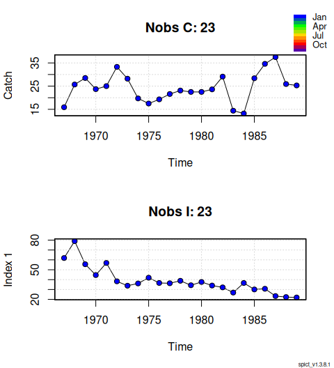

```r
plotspict.data(pol$albacore)
```

Note that the number of catch and index observations are given in the respective plot headers. Furthermore, the color of individual points shows when the observation was made and the corresponding colors are shown in the color legend in the top right corner. For illustrative purposes let’s try shifting the biomass index data a bit

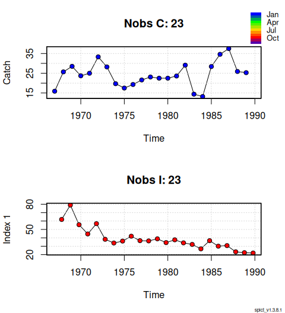

```r
inpshift <- pol$albacore
inpshift$timeC <- inpshift$timeC
inpshift$timeI <- inpshift$timeI + 0.8
plotspict.data(inpshift)
```

Now the colours show that the index takes place in autumn.

## 1.4 Advanced data plotting

There is also a more advanced function for plotting data, which at the same time does some basic model fitting (linear regression) and shows the results

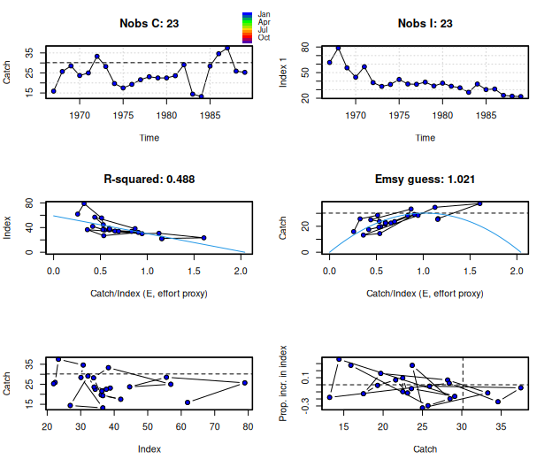

```r
plotspict.ci(pol$albacore)
```

The two top plots come from `plotspict.data`, with the dashed horizontal line representing a guess of MSY. This guess comes from a linear regression between the index and the catch divided by the index (middle row, left). This regression is expected to have a negative slope. A similar plot can be made showing catch versus catch/index (middle row, right) to approximately find the optimal effort (or effort proxy). The proportional increase in the index as a function of catch (bottom row, right) should show primarily positive increases in index at low catches and vice versa. Positive increases in index at large catches could indicate model violations. In the current plot these are not seen.

## 1.5 Fitting the model

The model is fitted to data by running

```r
res <- fit.spict(pol$albacore)
```

The results are returned as a list that contains output as well as input. The content of this list is

```r
names(res)
    [1] "value"           "sd"              "cov"             "par.fixed"
    [5] "cov.fixed"       "pdHess"          "gradient.fixed"  "par.random"
    [9] "diag.cov.random" "env"             "plsd"            "inp"
   [13] "obj"             "opt"             "pl"              "Cp"
   [17] "report"          "spict.version"   "computing.time"
```

Many of these variables are generated by `TMB::sdreport()`. In addition to these `spict` includes the list of input values (`inp`), the object used for fitting (`obj`), the result from the optimiser (`opt`), the time spent on fitting the model (`computing.time`), and more less useful variables.

## 1.6 Interpreting summary of results

The results are summarised using

```r
summary(res)
```

```
    [1] "Convergence: 0  MSG: relative convergence (4)"
    [2] "Objective function at optimum: 2.0654938"
    [3] "Euler time step (years):  1/16 or 0.0625"
    [4] "Nobs C: 23,  Nobs I1: 23"
    [5] ""
    [6] "Priors"
    [7] "     logn  ~  dnorm[log(2), 2^2]"
    [8] " logalpha  ~  dnorm[log(1), 2^2]"
    [9] "  logbeta  ~  dnorm[log(1), 2^2]"
   [10] ""
   [11] "Model parameter estimates w 95% CI "
   [12] "           estimate       cilow       ciupp    log.est  "
   [13] " alpha    8.5380743   1.2233111  59.5913111  2.1445355  "
   [14] " beta     0.1212598   0.0180697   0.8137358 -2.1098202  "
   [15] " r        0.2556012   0.1010608   0.6464620 -1.3641371  "
```

[output cut: 37 more lines]

Here is a line-by-line description of the summary:

- Line 1: Convergence of the model fit, which has code 0 if the fit was succesful. If this is not the case convergence was not obtained and reported results should not be used. In case of non-convergence results will still be reported to aid diagnosis of the problem.
- Line 2: Objective function value at the optimum. The objective function is the likelihood function if priors are not used and the posterior density function if priors are used.
- Line 3: The Euler time step used in the calculation.
- Line 4: Number of observations for the time series used.
- Line 6-9: Summary of the priors used in the fit. The priors shown here are the default priors that are applied when priors are unspecified. These are relatively uninformative and are applied because most data-limited situations do not allow simultaneous estimation of all noise parameters and `logn`. The default priors can be disabled (see the section on priors).
- Line 11-25: Summary of the parameter estimates and their 95% CIs. These can be extracted as a data frame with `sumspict.parest(res)`.
- Line 27-31: Estimates of deterministic reference points with 95% CIs. These are the reference points one would derive if stochasticity were ignored. Can be extracted with `sumspict.drefpoints(res)`.
- Line 32-36: Estimates of stochastic reference points with 95% CIs. These are the reference points of the stochastic model. The column ´rel.diff.Drp´ shows the relative difference when compared to the deterministic reference points. The information can be extracted with `sumspict.srefpoints(res)`.
- Line 38-43: State estimates in the final year where data were available. The states of the model are biomass (`B`) and fishing mortality (`F`) with the year of the estimates appended. The year is shown as a decimal number as estimates within year are possible. Both absolute (`B` and `F`) and relative estimates (`B/Bmsy` and `F/Fmsy`) are shown. The relative estimates are calculated using the type of reference points given by `msytype` (line 38), where `s` is stochastic and `d` is deterministic. Here `msytype` is ´s´. This information can be extracted using `sumspict.states(res)`.
- Line 45-52: Predictions of absolute and relative biomass and fishing mortality at the time indicated by `inp$timepredi`, here 1990 (line 47-50). In addition, predicted catch at the time indicated by `inp$timepredc` (line 51). Finally, the equilibrium biomass, indicated by E(B_inf), if current conditions remain constant. There predictions or forecasts are calculated under the fishing scenario given by `inp$ffac`. See the section on forecasting for more information. The prediction summary can be extracted using `sumspict.predictions(res)`.

## 1.7 Interpreting plots of results

`spict` comes with several plotting abilities. The basic plotting of the results is done using the generic function `plot` that produces a multipanel plot with the most important outputs.

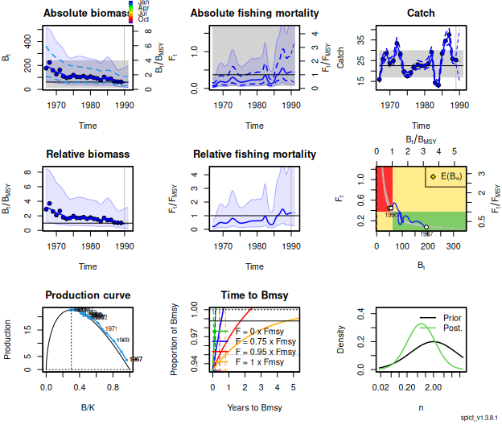

```r
plot(res)
```

Some general comments can be made regarding the style and colours of these plots:

- Estimates (biomass, fishing mortality, catch, production) are shown using blue lines.
- 95% CIs of absolute quantities are shown using dashed blue lines.
- 95% CIs of relative biomass and fishing mortality are shown using shaded blue regions.
- Estimates of reference points ($B_{MSY}$, $F_{MSY}$, $MSY$) are shown using black lines.
- 95% CIs of reference points are shown using grey shaded regions.
- The end of the data range is shown using a vertical grey line.
- Predictions beyond the data range are shown using dotted blue lines.
- Data are shown using points colored by season. Different index series use different point characters (not shown here).

The individual plots can be plotted separately using the `plotspict.*` family of plotting functions; all functions are summarised in Table 1 and their common arguments that control their look in Table 2:

Available plotting functions.

[output not shown]

Common arguments in the `plotspict.*` family of funtions

| Argument | Value | Result |
| --- | --- | --- |
| `logax` | logical | If `TRUE`, the y-axis is in log scale |
| `main` | string | The title of the plot |
| `ylim` | numeric vector | The limits of the y-axis |
| `plot.obs` | logical | If `TRUE` (default) the observations are shown |
| `qlegend` | logical | If `TRUE` (default) the color legend is shown |
| `xlab`, `ylab` | string | The x and y axes labels |
| `stamp` | string | Adds a “stamp” at the bottom right corner of the plotting area |
|  |  | Default is the version and SHA hash of `spict`. |
|  |  | An empty string removes the stamp. |

We will now look at them one at a time. The top left is the plot of absolute biomass

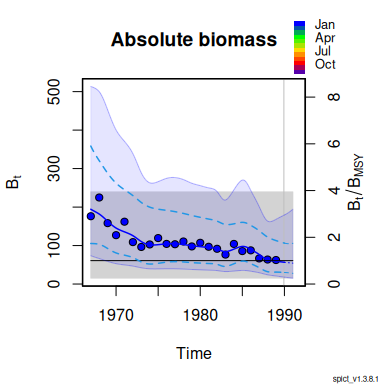

```r
plotspict.biomass(res)
```

Note that this plot has a y-axis on the right side related to the relative biomass ($B_t/B_{MSY}$). The shaded 95% CI region relates to this axis, while the dashed blue lines relate to the left y-axis indicating absolute levels. The dashed lines and the shaded region are shown on the same plot to make it easier to assess whether the relative or absolute levels are most accurately estimated. Here, the absolute are more accurate than the relative. Later, we will see examples of the opposite. The horizontal black line is the estimate of $B_{MSY}$ with 95% CI shown as a grey region.

The plot of the relative biomass is produced using

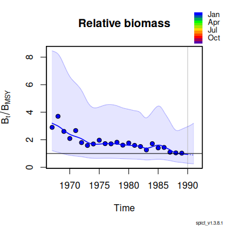

```r
plotspict.bbmsy(res)
```

This plot contains much of the same information as given by `plotspict.biomass`, but without the information about absolute biomass and without the 95% CI around the $B_{MSY}$ reference point.

The plots of fishing mortality follow the same principles

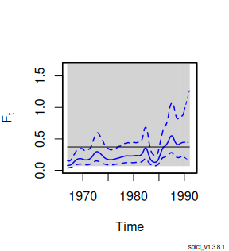

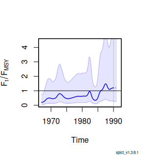

```r
plotspict.f(res, main='', qlegend=FALSE, rel.axes=FALSE, rel.ci=FALSE)
plotspict.ffmsy(res, main='', qlegend=FALSE)
```

The estimate of $F_{MSY}$ is shown with a horizontal black line with 95% CI shown as a grey region (left plot). The 95% CI of $F_{MSY}$ is very wide in this case. As shown here it is quite straightforward to remove the information about relative levels from the plot of absolute fishing mortality. Furthermore, the argument `main=''` removes the heading and `qlegend=FALSE` removes the colour legend for data points.

The plot of the catch is produced using

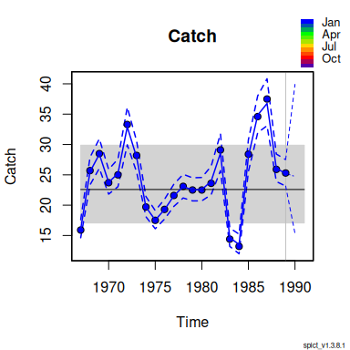

```r
plotspict.catch(res)
```

This plot shows estimated catches (blue line) versus observed catches (points) with the estimate of $MSY$ plotted as a horizontal black line with its 95% CI given by the grey region.

A phase plot (or kobe plot) of fishing mortality versus biomass is plotted using

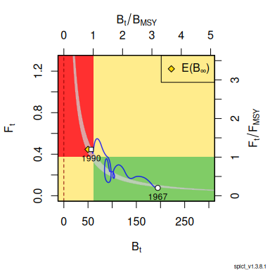

```r
plotspict.fb(res, ylim=c(0, 1.3), xlim=c(0, 300))
```

The plot shows the development of biomass and fishing mortality since the initial year (here 1967) indicated with a circle until the terminal year (here 1990) indicated with a square. The yellow diamond indicates the mean biomass over a long period if the current (1990) fishing pressure remains. This point can be interpreted as the fished equilibrium and is denoted $E(B_\infty)$ in the legend as a statistical way of expressing the expectation of the biomass as $t \rightarrow \infty$. As the current fishing mortality is close to $F_{MSY}$ the expected long term biomass is close to $B_{MSY}$.

A vertical dashed red line at $B_t = 0$ indicates the biomass level below which the stock has crashed. The grey shaded banana-shaped area indicates the 95% confidence region of the pair $F_{MSY}$, $B_{MSY}$. This region is important to visualise jointly as the two reference points are highly (negatively) correlated.

## 1.8 Residuals and diagnostics

Before proceeding with the results for an actual assessment it is very important that the model residuals are checked and possible model deficiencies identified. Residuals can be calculated using `calc.osa.resid()`. OSA stands for one-step-ahead, which are the proper residuals for state-space models. More information about OSA residuals is contained in Pedersen and Berg (2017). To calculate and plot residuals and diagnostics do

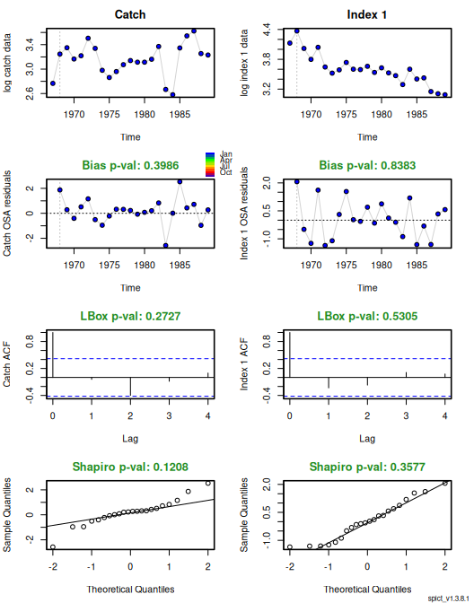

```r
res <- calc.osa.resid(res)
plotspict.diagnostic(res)
```

The first column of the plot contains information related to catch data and the second column contains information related to the index data. The rows contain

1. Log of the input data series.
2. OSA residuals with the p-value of a test for bias (i.e. that the mean of the residuals is different from zero) in the plot header. If the header is green the test was not significant, otherwise the header would be red.
3. Empirical autocorrelation of the residuals. Two tests for significant autocorrelation is performed. A Ljung-Box simultaneous test of multiple lags (here 4) with p-value shown in the header, and tests for individual lags shown by dashed horizontal lines in the plot. Here no violation is identified.
4. Tests for normality of the residuals both as a QQ-plot and with a Shapiro test with p-value shown in the plot header.

This data did not have any significant violations of the assumptions, which increases confidence in the results. For a discussion of possible violations and remedies the reader is referred to Pedersen and Berg (2017).

### 1.8.1 Process residuals

The function `calc.process.resid()` calculates and adds the process residuals as a `data.frame`. It takes the fitted object and `dt` as arguments. `dt` has by default the same resolution as the input data, i.e. `1/inp$nseasons`.

Function `plotspict.diagnostic.process()` plots the process residuals for the the biomass and fishing mortality processes. The plot is similar to that produced by `plotspict.diagnostic`, see above for the description.

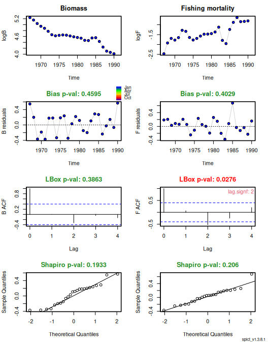

```r
res <- calc.process.resid(res)
plotspict.diagnostic.process(res)
```

## 1.9 Extracting parameter estimates

To extract an estimated quantity, here `logBmsy` use

```r
get.par('logBmsy', res)
                 ll      est       ul        sd       cv
   logBmsy 2.734598 4.106544 5.478489 0.6999851 0.170456
```

This returns a vector with `ll` being the lower 95% limit of the CI, `est` being the estimated value, `ul` being the upper 95% limit of the CI, `sd` being the standard deviation of the estimate, and `cv` being the coefficient of variation of the estimate. The estimated quantity can also be returned on the natural scale (as opposed to log scale) by running

```r
get.par('logBmsy', res, exp=TRUE)
                 ll      est       ul        sd        cv
   logBmsy 15.40355 60.73644 239.4847 0.6999851 0.7951617
```

This essentially takes the exponential of `ll`, `est` and `ul` of the values in log, while `sd` is unchanged as it is the standard deviation of the quantity on the scale that it is estimated (here log). When transforming using `exp=TRUE` the $CV = \sqrt{e^{\sigma^2}-1}$. Most parameters are log-transformed under estimation and should therefore be extracted using `exp=TRUE`.

For a standard fit (not using robust observation error, seasonality etc.), the quantities that can be extracted using this method are

```r
list.quantities(res)
    [1] "Bm"                 "Bmsy"               "Bmsy2"
    [4] "BmsyB0"             "Bmsyd"              "Bmsys"
    [7] "Cp"                 "Emsy"               "Emsy2"
   [10] "Fmsy"               "Fmsyd"              "Fmsys"
   [13] "gamma"              "isdb2"              "isdc2"
   [16] "isde2"              "isdf2"              "isdi2"
   [19] "K"                  "logalpha"           "logB"
   [22] "logBBmsy"           "logbeta"            "logbkfrac"
   [25] "logBl"              "logBlBmsy"          "logBlK"
   [28] "logBm"              "logBmBmsy"          "logBmK"
   [31] "logBmsy"            "logBmsyd"           "logBmsyPluslogFmsy"
   [34] "logBmsys"           "logBp"              "logBpBmsy"
   [37] "logBpK"             "logCp"              "logCpred"
   [40] "logEmsy"            "logEmsy2"           "logEp"
   [43] "logF"               "logFFmsy"           "logFFmsynotS"
   [46] "logFl"              "logFlFmsy"          "logFlFmsynotS"
   [49] "logFm"              "logFmFmsy"          "logFmFmsynotS"
   [52] "logFmsy"            "logFmsyd"           "logFmsys"
   [55] "logFnotS"           "logFp"              "logFpFmsy"
   [58] "logFpFmsynotS"      "logFs"              "logIp"
   [61] "logIpred"           "logK"               "logm"
   [64] "logMSY"             "logMSYd"            "logMSYs"
   [67] "logn"               "logq"               "logq2"
   [70] "logr"               "logrc"              "logrold"
   [73] "logsdb"             "logsdc"             "logsdf"
   [76] "logsdi"             "m"                  "MSY"
   [79] "MSYd"               "MSYs"               "p"
   [82] "q"                  "r"                  "rc"
   [85] "rold"               "sdb"                "sdc"
   [88] "sde"                "sdf"                "sdi"
   [91] "seasonsplinefine"
```

These should be relatively self-explanatory when knowing that reference points ending with `s` are stochastic and those ending with `d` are deterministic, quantities ending with `p` are predictions and quantities ending with `l` are estimates in the final year. If a quantity is available both on natural and log scale, it is preferred to transform the quantity from log as most quantities are estimated on the log scale.

### 1.9.1 Extracting correlation between parameter estimates

The covariance between the model parameters (fixed effects) can be extracted from the results list

```r
res$cov.fixed
                   logm         logK         logq         logn       logsdb
   logm    0.0204040267 -0.005706715  0.026834550 -0.156740711  0.032240094
   logK   -0.0057067147  0.037105157 -0.038074891 -0.011343171 -0.021784058
   logq    0.0268345498 -0.038074891  0.091311217 -0.227633746  0.040958405
   logn   -0.1567407113 -0.011343171 -0.227633746  1.473743203 -0.190011570
   logsdb  0.0322400939 -0.021784058  0.040958405 -0.190011570  0.980089550
   logsdf  0.0014253360 -0.002407435  0.003270276 -0.006648029 -0.002144232
   logsdi -0.0007603785 -0.002521057  0.002848540  0.007158236  0.010535582
   logsdc  0.0015535710  0.001300311 -0.008392547  0.001997837  0.137920143
                 logsdf        logsdi       logsdc
   logm    0.0014253360 -0.0007603785  0.001553571
   logK   -0.0024074350 -0.0025210569  0.001300311
   logq    0.0032702761  0.0028485402 -0.008392547
   logn   -0.0066480294  0.0071582364  0.001997837
   logsdb -0.0021442317  0.0105355816  0.137920143
   logsdf  0.0262881995 -0.0002784388 -0.035159489
   logsdi -0.0002784388  0.0237200095  0.005885861
   logsdc -0.0351594891  0.0058858615  0.846804275
```

It is however easier to interpret the correlation rather than covariance. The correlation matrix can be calculated using

```r
cov2cor(res$cov.fixed)
                 logm         logK        logq         logn      logsdb
   logm    1.00000000 -0.207401113  0.62169061 -0.903884552  0.22798458
   logK   -0.20740111  1.000000000 -0.65412307 -0.048507225 -0.11423226
   logq    0.62169061 -0.654123072  1.00000000 -0.620531274  0.13691407
   logn   -0.90388455 -0.048507225 -0.62053127  1.000000000 -0.15810160
   logsdb  0.22798458 -0.114232259  0.13691407 -0.158101598  1.00000000
   logsdf  0.06154303 -0.077082718  0.06674856 -0.033775486 -0.01335852
   logsdi -0.03456324 -0.084978309  0.06120725  0.038285798  0.06909843
   logsdc  0.01181902  0.007335649 -0.03018146  0.001788371  0.15139213
               logsdf      logsdi       logsdc
   logm    0.06154303 -0.03456324  0.011819025
   logK   -0.07708272 -0.08497831  0.007335649
   logq    0.06674856  0.06120725 -0.030181458
   logn   -0.03377549  0.03828580  0.001788371
   logsdb -0.01335852  0.06909843  0.151392130
   logsdf  1.00000000 -0.01115044 -0.235651720
   logsdi -0.01115044  1.00000000  0.041529919
   logsdc -0.23565172  0.04152992  1.000000000
```

For this data most parameters are well separated, i.e. relatively low correlation, perhaps with the exception of `logm` and `logn`, which have a correlation of $-0.9$. Note that `logr` is absent from the covariance matrix. This is because the model is parameterised in terms of `logm`, `logK`, and `logn` from which `logr` can be derived. The estimate of `logr` is reported using TMB’s `sdreport()` function and can be extracted using `get.par()`.

The covariance between random effects (biomass and fishing mortality) is not reported automatically, but can be obtained by setting `inp$getJointPrecision` to `TRUE` (this entails longer computation time and memory requirement).

The covariance between sdreported values (i.e. the values reported in `res$value`) are given in `res$cov`. As this matrix is typically large, the function `get.cov()` can be used to extract the covariance between two scalar quantities

```r
cov2cor(get.cov(res, 'logBmsy', 'logFmsy'))
              [,1]       [,2]
   [1,]  1.0000000 -0.9982507
   [2,] -0.9982507  1.0000000
```

This reveals that for this data set the estimates of log Fmsy and log Bmsy are highly correlated. This is often the case and the reason why the model is reparameterised.

## 1.10 Comparison plots

The function `plotspict.compare()` can be used to make comparison plots of one or more spict runs. The function is able to show biomass and fishing mortality (absolute and relative), catch, and production curve. You can use the `varname` argument to select which of those plots to produce, default is all of them (`c("B", "F", "C", "BBmsy", "FFmsy", "P")`).

As an example we show below the comparison of two runs with and without logbkfrac prior.

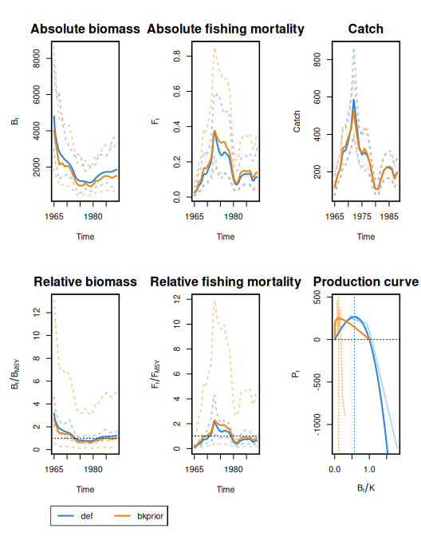

```r
data(pol)
inp <- pol$hake
rep1 <- fit.spict(inp)
inp$priors$logbkfrac <- c(log(0.3), 0.1, 1)
rep2 <- fit.spict(inp)
plotspict.compare(list(def = rep1, bkprior = rep2))
```

# 2 Advanced functionality

## 2.1 Retrospective plots

Retrospective plots are sometimes used to evaluate the robustness of the model fit to the introduction of new data, i.e. to check whether the fit changes substantially when new data becomes available. Such calculations and plotting thereof can be performed using `retro()` as shown here

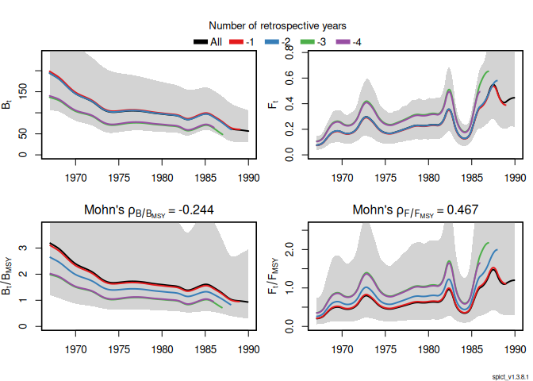

```r
## res <- fit.spict(pol$albacore)
res <- retro(res, nretroyear = 4, mc.cores = 1)
plotspict.retro(res)
        FFmsy      BBmsy
    0.4668541 -0.2441045
```

By default `retro` creates 5 scenarios with catch and index time series which are shortened by the 1 to 5 last observations. The number of scenarios and thus observations which are removed can be changed with the argument `nretroyear` in the function `retro`. The graphs show the different peels with different colors. For the relative biomass and fishing mortality, the Mohn’s rho are shown inside the corresponding plots. Mohn’s rho for other quantities can be calculated using the function `mohns_rho`.

```r
## res <- fit.spict(pol$albacore)
## res <- retro(res)
mohns_rho(res, what = c("FFmsy", "BBmsy"))
        FFmsy      BBmsy
    0.4668541 -0.2441045
```

The function `plotspict.retro.fixed` makes a plot of the paramter estimates, with corresponding 95% confidence intervals for each of the retrospective runs.

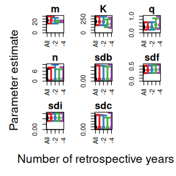

```r
## res <- fit.spict(pol$albacore)
## res <- retro(res)
plotspict.retro.fixed(res)
```

## 2.2 Estimation using two or more biomass indices

The estimation can be done using more than one biomass index, for example when scientific surveys are performed more than once every year or when there are both commercial and survey CPUE time-series available. The following example emulates a situation where a long but noisy first quarter index series and a shorter and less noisy second quarter index series are available with different catchabilities

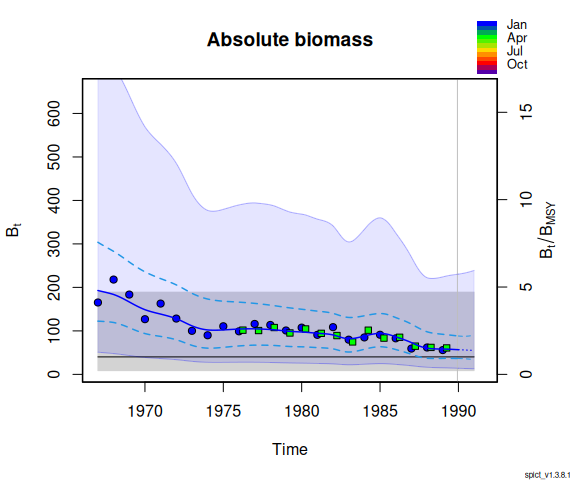

```r
set.seed(123)
inp <- list(timeC=pol$albacore$timeC, obsC=pol$albacore$obsC)
inp$timeI <- list(pol$albacore$timeI, pol$albacore$timeI[10:23]+0.25)
inp$obsI <- list()
inp$obsI[[1]] <- pol$albacore$obsI * exp(rnorm(23, sd=0.1)) # Index 1
inp$obsI[[2]] <- 10*pol$albacore$obsI[10:23] # Index 2
res <- fit.spict(inp)
sumspict.parest(res)
              estimate        cilow       ciupp    log.est
   alpha1   5.54953277   0.94907992  32.4496529  1.7137137
   alpha2   3.45424301   0.58225749  20.4922993  1.2396033
   beta     0.12057032   0.01913001   0.7599159 -2.1155222
   r        0.18601585   0.08916105   0.3880831 -1.6819234
   rc       1.20960485   0.19388362   7.5465058  0.1902937
   rold     0.26864004   0.05297139   1.3623857 -1.3143829
   m       24.30175995  17.98207999  32.8424485  3.1905488
   K      220.56430256 148.87830685 326.7676305  5.3961893
   q1       0.35403668   0.22557324   0.5556598 -1.0383547
   q2       3.60405907   2.32439323   5.5882290  1.2820607
   n        0.30756466   0.03135919   3.0165328 -1.1790699
   sdb      0.02006319   0.00372284   0.1081248 -3.9088686
   sdf      0.36879350   0.26948920   0.5046905 -0.9975184
   sdi1     0.11134131   0.08158825   0.1519445 -2.1951549
   sdi2     0.06930312   0.04587601   0.1046936 -2.6692653
   sdc      0.04446555   0.00764514   0.2586198 -3.1130406
plotspict.biomass(res)
```

The model estimates seperate observation noises and finds that the first index (`sdi1`) is more noisy than the second (`sdi2`). It is furthermore estimated that the catchabilities are different by a factor 10 (`q1` versus `q2`). The biomass plot shows both indices, with circles indicating the first index and squares indicating the second index (the two series can also be distinguished by their colours). It is possible to force the model to assume that two or more index time-series have the same level of observation noise (CV). For example, to assume that `sdi1` equals `sdi2` one must add `inp$mapsdi <- c(1,1)` before calling `fit.spict(inp)`. The length of `mapsdi` should equal the number of indices. In case of 3 index series one could for example use `inp$mapsdi <- c(1, 1, 2)` to have series 1 and 2 share sdi and have a separate sdi for series 3.

## 2.3 Using effort data instead of commercial CPUE

It is possible to use effort data directly in the model instead of calculating commercial CPUE and inputting this as an index. It is beyond the scope of this vignette to discuss all problems associated with indices based on commercial CPUEs, however it is intuitively clear that using the same information twice (catch as catch and catch in catch/effort) induces a correlation, which the model does not account for. These problems are easily avoided by putting catch and effort seperately

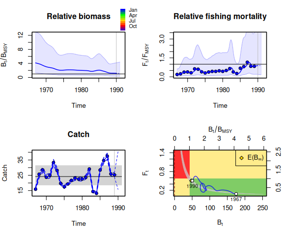

```r
inpeff <- list(timeC=pol$albacore$timeC, obsC=pol$albacore$obsC,
               timeE=pol$albacore$timeC, obsE=pol$albacore$obsC/pol$albacore$obsI)
repeff <- fit.spict(inpeff)
sumspict.parest(repeff)
              estimate        cilow        ciupp    log.est
   beta     0.07385348   0.01464766   0.37236912 -2.6056722
   r        0.23822940   0.10657013   0.53254364 -1.4345212
   rc       1.14399159   0.21452931   6.10041000  0.1345235
   rold     0.40826822   0.03851527   4.32771055 -0.8958309
   m       24.16376107  18.62126820  31.35593897  3.1848540
   K      189.53177350 132.49614300 271.11953867  5.2445567
   qf       0.41117179   0.25562849   0.66135914 -0.8887442
   n        0.41648802   0.04180369   4.14944841 -0.8758976
   sdb      0.01430671   0.00236760   0.08645135 -4.2470266
   sdf      0.37625010   0.27938937   0.50669121 -0.9775012
   sde      0.09820098   0.06985386   0.13805153 -2.3207391
   sdc      0.02778738   0.00568278   0.13587327 -3.5831734
par(mfrow=c(2, 2))
plotspict.bbmsy(repeff)
plotspict.ffmsy(repeff, qlegend=FALSE)
plotspict.catch(repeff, qlegend=FALSE)
plotspict.fb(repeff)
```

Here the model runs without an index of biomass and instead uses effort as an index of fishing mortality Note that index observations are missing from the biomass plot, but effort observations are present in the plot of fishing mortality. Note also that `q` is missing from the summary of parameter estimates and instead `qf` is present, which is the commercial catchability.

Overall for this data set the results in terms of stock status etc. do not change much, and this will probably often be the case, however using effort data directly instead of commercial CPUE is cleaner and avoids inputting the same data twice.

## 2.4 Scaling the uncertainty of individual data points

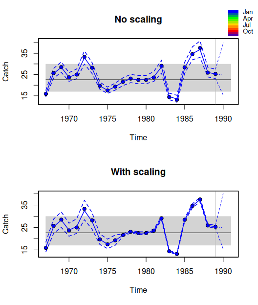

```r
inp <- pol$albacore
res1 <- fit.spict(inp)
inp$stdevfacC <- rep(1, length(inp$obsC))
inp$stdevfacC[1:10] <- 5
res2 <- fit.spict(inp)
par(mfrow=c(2, 1))
plotspict.catch(res1, main='No scaling')
plotspict.catch(res2, main='With scaling', qlegend=FALSE)
```

From the plot it is noted that the scaling factor widens the 95% CIs of the initial ten years of catch data, while narrowing the 95% CIs of the remaining years.

## 2.5 Simulating data

The package has built-in functionality for simulating data, which is useful for testing.

### 2.5.1 Annual data

Data are simulated using an input list, e.g. `inp`, containing parameter values specified in `inp$ini`. To simulate data using default parameters run

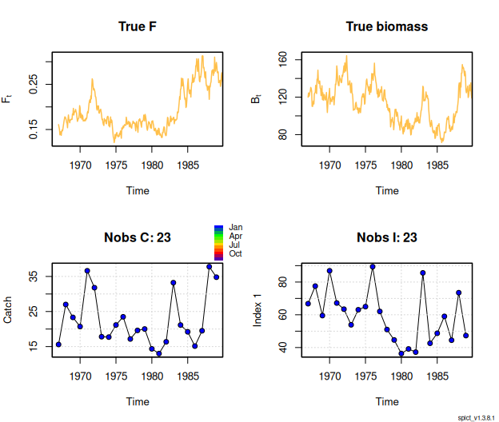

```r
inp <- check.inp(pol$albacore)
sim <- sim.spict(inp)
   The stabilise option was used for fitting / is specified in the input list (inp$stabilise). This activates six very vague priors. Acknowledging these priors when simulating is not yet implemented.
   Additional priors were used for fitting / are specified in the input list (inp$priors): logn, logalpha, logbeta. Acknowledging these priors when simulating is not yet implemented.
plotspict.data(sim)
```

This will generate catch and index data of same length as the input catch and index time series (here 23 of each) at the time points of the input data. Note when plotting simulated data, the true biomass and fishing mortality are also included in the plot.

Another simple example is

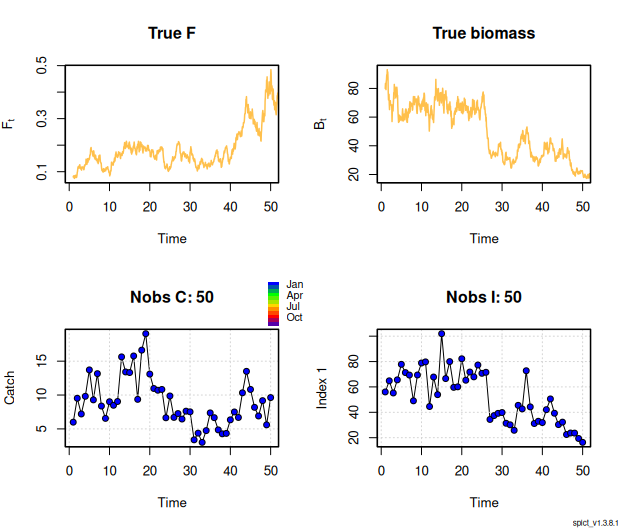

```r
inp <- list(ini=list(logK=log(100), logm=log(10), logq=log(1)))
sim <- sim.spict(inp, nobs=50)
   The stabilise option was used for fitting / is specified in the input list (inp$stabilise). This activates six very vague priors. Acknowledging these priors when simulating is not yet implemented.
   Additional priors were used for fitting / are specified in the input list (inp$priors): logn, logalpha, logbeta. Acknowledging these priors when simulating is not yet implemented.
plotspict.data(sim)
```

Here the required parameters are specified (the rest use default values), and the number of observations is specified as an argument to `sim.spict()`.

A more customised example including model fitting is

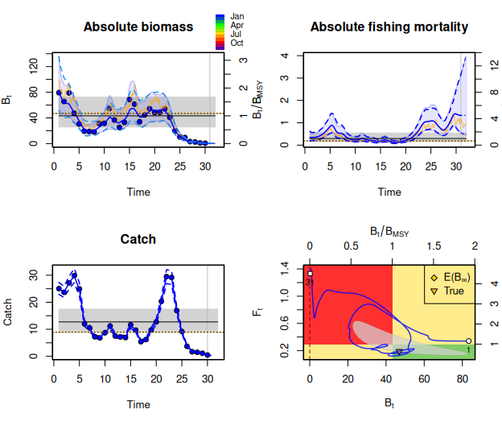

```r
set.seed(31415926)
inp <- list(ini=list(logK=log(100), logm=log(10), logq=log(1),
                     logbkfrac=log(1), logF0=log(0.3), logsdc=log(0.1),
                     logsdf=log(0.3)))
sim <- sim.spict(inp, nobs=30)
   The stabilise option was used for fitting / is specified in the input list (inp$stabilise). This activates six very vague priors. Acknowledging these priors when simulating is not yet implemented.
   Additional priors were used for fitting / are specified in the input list (inp$priors): logn, logalpha, logbeta. Acknowledging these priors when simulating is not yet implemented.
res <- fit.spict(sim)
sumspict.parest(res)
             estimate  true       cilow       ciupp true.in.ci     log.est
   alpha   1.04607702  -9.0  0.31605055   3.4623485         -9  0.04504700
   beta    0.13191760  -9.0  0.02269952   0.7666352         -9 -2.02557780
   r       1.07672257  -9.0  0.35062213   3.3064983         -9  0.07392177
   rc      0.63474120  -9.0  0.34468650   1.1688778         -9 -0.45453793
   rold    0.45001541  -9.0  0.22253267   0.9100411         -9 -0.79847346
   m      14.48076847  10.0 10.46879064  20.0302655          0  2.67282146
   K      76.02606659 100.0 46.11361253 125.3417914          1  4.33107626
   q       1.19617689   1.0  0.85014237   1.6830583          1  0.17913055
   n       3.39263489   2.0  1.36227811   8.4490615          1  1.22160687
   sdb     0.19525937   0.2  0.08858085   0.4304115          1 -1.63342650
   sdf     0.34363005   0.3  0.25198877   0.4685987          1 -1.06818964
   sdi     0.20425634   0.2  0.12167035   0.3428991          1 -1.58837951
   sdc     0.04533085   0.1  0.00814495   0.2522895          1 -3.09376744
par(mfrow=c(2, 2))
plotspict.biomass(res)
plotspict.f(res, qlegend=FALSE)
plotspict.catch(res, qlegend=FALSE)
plotspict.fb(res)
```

Here the ratio between biomass in the initial year relative to `K` is set using `logbkfrac`, the initial fishing mortality is set using `logF0`, process noise of `F` is set using `logsdf`, and finally observation noise on catches is specified using `logsdc`.

When printing the summary of the parameter estimates the true values are included as well as a check whether the true value was inside the 95% CIs. Similarly, the true biomass, fishing mortality, and reference points are included in the results plot using a yellow/orange colour.

### 2.5.2 Seasonal data

It is possible to simulate seasonal data (most often quarterly). Additional variables must be specified in the input list that define the type of seasonality to be used. Spline based seasonality is shown first (`inp$seasontype = 1`). This is the default and therefore does not need to be explicitly specified. It is required that number of seasons is specified using `nseasons` (4 indicates quarterly), the order of the spline must be specified using `splineorder` (3 for quarterly data), time vectors for catch and index containing subannual time points must be specified, and finally the spline parameters (`logphi`) must be set. With four seasons `logphi` must be a vector of length 3, where each value in the vector gives the log fishing intensity relative to level in season four, which is `log(1)`. An example of simulating seasonal data using a spline is

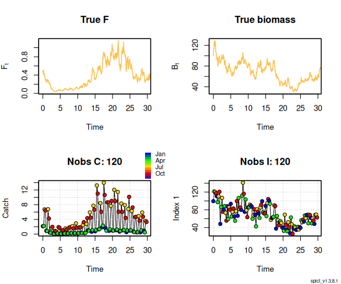

```r
set.seed(1234)
inp <- list(nseasons=4, splineorder=3)
inp$timeC <- seq(0, 30-1/inp$nseasons, by=1/inp$nseasons)
inp$timeI <- seq(0, 30-1/inp$nseasons, by=1/inp$nseasons)
inp$ini <- list(logK=log(100), logm=log(20), logq=log(1),
                logbkfrac=log(1), logsdf=log(0.4), logF0=log(0.5),
                logphi=log(c(0.05, 0.1, 1.8)))
seasonsim <- sim.spict(inp)
   The stabilise option was used for fitting / is specified in the input list (inp$stabilise). This activates six very vague priors. Acknowledging these priors when simulating is not yet implemented.
   Additional priors were used for fitting / are specified in the input list (inp$priors): logn, logalpha, logbeta. Acknowledging these priors when simulating is not yet implemented.
plotspict.data(seasonsim)
```

The data plot shows clear seasonality in the catches. To simulate seasonal data using the coupled SDE approach `seasontype` must be set to 2 and `nseasons` to 4.

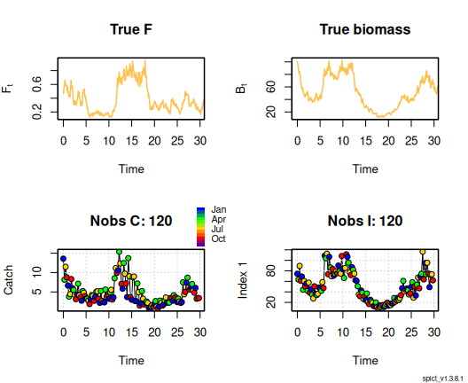

```r
set.seed(432)
inp <- list(nseasons=4, seasontype=2)
inp$timeC <- seq(0, 30-1/inp$nseasons, by=1/inp$nseasons)
inp$timeI <- seq(0, 30-1/inp$nseasons, by=1/inp$nseasons)
inp$ini <- list(logK=log(100), logm=log(20), logq=log(1),
                logbkfrac=log(1), logsdf=log(0.4), logF0=log(0.5))
seasonsim2 <- sim.spict(inp)
   The stabilise option was used for fitting / is specified in the input list (inp$stabilise). This activates six very vague priors. Acknowledging these priors when simulating is not yet implemented.
   Additional priors were used for fitting / are specified in the input list (inp$priors): logn, logalpha, logbeta. Acknowledging these priors when simulating is not yet implemented.
plotspict.data(seasonsim2)
```

## 2.6 Estimation using quarterly data

1. using cyclic B-splines.
2. using coupled stochastic differential equations (SDEs).
3. combination of a cyclic spline (fixed seasonal pattern) and mean-zero autoregressive process

Technical description of the first two season types is found in Pedersen and Berg (2017). The third is described by the following equation:

$$\begin{align}
F_t &= S_t G_t \exp( A_{q(t)} ) \\
d\log G_t &= \sigma_FdV_t
\end{align}$$

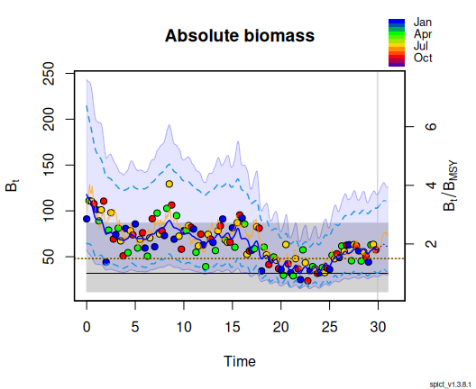

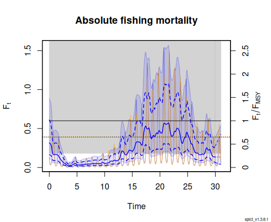

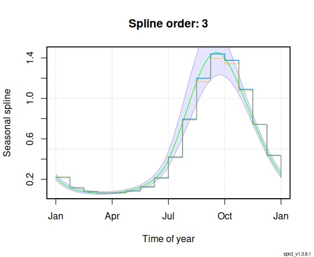

```r
seasonres <- fit.spict(seasonsim)
plotspict.biomass(seasonres)
plotspict.f(seasonres, qlegend=FALSE)
plotspict.season(seasonres)
```

The model is able to estimate the seasonal variation in fishing mortality as seen both in the plot of `F` and in the plot of the estimated spline, where blue is the estimated spline, orange is the true spline, and green is the spline if time were truly continuous (it is discretised with the Euler steps shown by the blue line).

To fit the coupled SDE model run

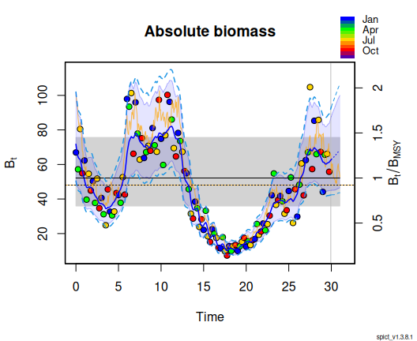

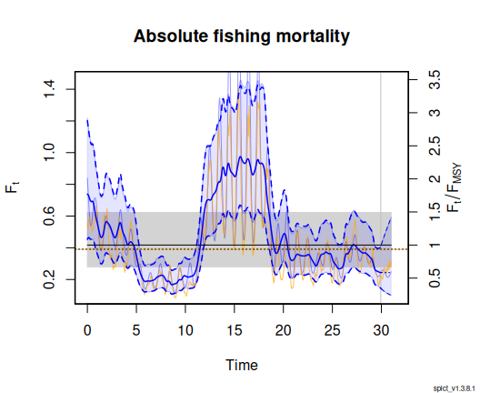

```r
seasonres2 <- fit.spict(seasonsim2)
sumspict.parest(seasonres2)
             estimate  true       cilow       ciupp true.in.ci    log.est
   alpha    1.1638023  -9.0  0.67490900   2.0068420         -9  0.1516925
   beta     0.4961820  -9.0  0.30347474   0.8112590         -9 -0.7008124
   r        0.8526429  -9.0  0.26693953   2.7234630         -9 -0.1594145
   rc       0.8468345  -9.0  0.56021630   1.2800925         -9 -0.1662500
   rold     0.8411047  -9.0  0.42324333   1.6715141         -9 -0.1730391
   m       22.6501790  20.0 18.08395652  28.3693785          1  3.1201677
   K      106.7057743 100.0 61.53788860 185.0262094          1  4.6700753
   q        1.1111248   1.0  0.81097414   1.5223647          1  0.1053729
   n        2.0137179   2.0  0.84869983   4.7779668          1  0.6999827
   sdb      0.1619837   0.2  0.10231809   0.2564425          1 -1.8202597
   sdu      0.1259182   0.1  0.07102504   0.2232368          1 -2.0721225
   sdf      0.3565348   0.4  0.25806033   0.4925867          1 -1.0313233
   sdi      0.1885170   0.2  0.15969214   0.2225448          1 -1.6685672
   sdc      0.1769062   0.2  0.13548625   0.2309887          1 -1.7321357
   lambda   0.1032635   0.1  0.02267910   0.4701842          1 -2.2704711
plotspict.biomass(seasonres2)
plotspict.f(seasonres2, qlegend=FALSE)
```

Two parameters related to the coupled SDEs are estimated (`sdu` and `lambda`) as evident from the summary of estimated parameters. In the plot of fishing mortality it is noted that the amplitude of the seasonal pattern varies over time. This is a property of the coupled SDE model, which is not possible to obtain with the spline based seasonal model. The spline based model has a fixed amplitude and phases, which will lead to biased estimates and autocorrelation in residuals if in reality the seasonal pattern shifts a bit. This is illustrated by fitting a spline based model to data generated with a coupled SDE model

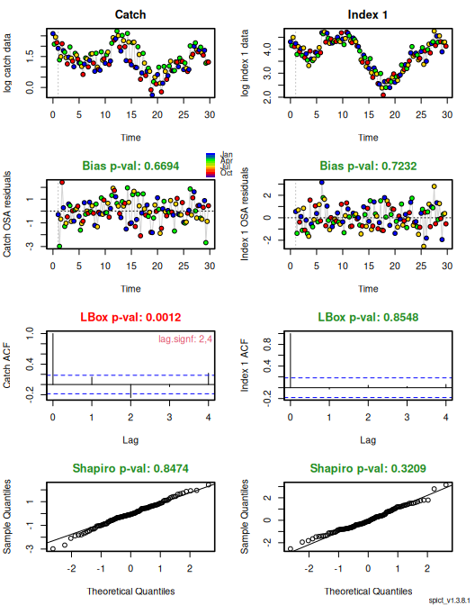

```r
inp2 <- list(obsC=seasonsim2$obsC, obsI=seasonsim2$obsI,
             timeC=seasonsim2$timeC, timeI=seasonsim2$timeI,
             seasontype=1, true=seasonsim2$true)
rep2 <- fit.spict(inp2)
rep2 <- calc.osa.resid(rep2)
plotspict.diagnostic(rep2)
```

From the diagnostics it is clear that autocorrelation is present in the catch residuals.

## 2.7 Setting initial parameter values

Initial parameter values used as starting guess of the optimiser can be set using `inp$ini`. For example, to specify the initial value of `logK` set

```r
inp <- pol$albacore
inp$ini$logK <- log(100)
```

This procedure generalises to all other model parameters. If initial values are not specified they are set to default values. To see the default initial value of a parameter, here `logK`, run

```r
inp <- check.inp(pol$albacore)
inp$ini$logK
   [1] 5.010635
```

This can also be done posterior to fitting the model by printing `res$inp$ini$logK`.

### 2.7.1 Checking robustness to initial parameter values

It is prudent to check that the same parameter estimates are obtained if using different initial values. If the optimum of the objective function is poorly defined, i.e. possibly containing multiple optima, it is possible that different parameter estimates will be returned depending on the initial values. To check whether this is the case run

```r
set.seed(123)
check.ini(pol$albacore, ntrials=4)
   Checking sensitivity of fit to initial parameter values...
    Trial 1 ... model fitted!
    Trial 2 ... model fitted!
    Trial 3 ... model fitted!
    Trial 4 ... model fitted!
   $propchng
            logm  logK  logq  logn logsdb logsdf logsdi logsdc
   Trial 1 -1.41  0.26 -0.12 -2.75  -1.26   1.30  -0.08  -1.12
   Trial 2  0.34 -0.04  0.62  0.34  -0.51  -0.21   1.14  -1.14
   Trial 3 -1.69 -0.42 -0.23 -3.26  -1.11  -0.55  -0.40  -1.41
   Trial 4  1.03  0.19  0.06 -0.68   0.60   1.01  -1.32  -1.15

   $inimat
           Distance  logn logK logm  logq logsdb logsdf logsdi logsdc
   Basevec     0.00  0.69 5.01 3.41 -0.64  -1.61  -1.61  -1.61  -1.61
   Trial 1     4.22 -0.29 6.34 2.99  1.12   0.42  -3.70  -1.48   0.20
   Trial 2     3.48  0.93 4.81 5.51 -0.86  -0.79  -1.27  -3.44   0.23
   Trial 3     4.52 -0.48 2.90 2.61  1.45   0.18  -0.72  -0.96   0.67
   Trial 4     3.64  1.41 5.97 3.61 -0.21  -2.58  -3.23   0.52   0.24

   $resmat
           Distance     m      K    q    n  sdb  sdf  sdi  sdc
   Basevec        0 22.58 201.48 0.35 0.69 0.01 0.37 0.11 0.04
   Trial 1        0 22.58 201.48 0.35 0.69 0.01 0.37 0.11 0.04
   Trial 2        0 22.58 201.48 0.35 0.69 0.01 0.37 0.11 0.04
   Trial 3        0 22.58 201.48 0.35 0.69 0.01 0.37 0.11 0.04
   Trial 4        0 22.58 201.48 0.35 0.69 0.01 0.37 0.11 0.04
   $obsC
    [1] 15.9 25.7 28.5 23.7 25.0 33.3 28.2 19.7 17.5 19.3 21.6 23.1 22.5 22.5 23.6
   [16] 29.1 14.4 13.2 28.4 34.6 37.5 25.9 25.3

   $timeC
    [1] 1967 1968 1969 1970 1971 1972 1973 1974 1975 1976 1977 1978 1979 1980 1981
   [16] 1982 1983 1984 1985 1986 1987 1988 1989

   $obsI
    [1] 61.89 78.98 55.59 44.61 56.89 38.27 33.84 36.13 41.95 36.63 36.33 38.82
   [13] 34.32 37.64 34.01 32.16 26.88 36.61 30.07 30.75 23.36 22.36 21.91

   $timeI
    [1] 1967 1968 1969 1970 1971 1972 1973 1974 1975 1976 1977 1978 1979 1980 1981
   [16] 1982 1983 1984 1985 1986 1987 1988 1989

   $check.ini
   $check.ini$propchng
            logm  logK  logq  logn logsdb logsdf logsdi logsdc
   Trial 1 -1.41  0.26 -0.12 -2.75  -1.26   1.30  -0.08  -1.12
   Trial 2  0.34 -0.04  0.62  0.34  -0.51  -0.21   1.14  -1.14
   Trial 3 -1.69 -0.42 -0.23 -3.26  -1.11  -0.55  -0.40  -1.41
   Trial 4  1.03  0.19  0.06 -0.68   0.60   1.01  -1.32  -1.15

   $check.ini$inimat
           Distance  logn logK logm  logq logsdb logsdf logsdi logsdc
   Basevec     0.00  0.69 5.01 3.41 -0.64  -1.61  -1.61  -1.61  -1.61
   Trial 1     4.22 -0.29 6.34 2.99  1.12   0.42  -3.70  -1.48   0.20
   Trial 2     3.48  0.93 4.81 5.51 -0.86  -0.79  -1.27  -3.44   0.23
   Trial 3     4.52 -0.48 2.90 2.61  1.45   0.18  -0.72  -0.96   0.67
   Trial 4     3.64  1.41 5.97 3.61 -0.21  -2.58  -3.23   0.52   0.24

   $check.ini$resmat
           Distance     m      K    q    n  sdb  sdf  sdi  sdc
   Basevec        0 22.58 201.48 0.35 0.69 0.01 0.37 0.11 0.04
   Trial 1        0 22.58 201.48 0.35 0.69 0.01 0.37 0.11 0.04
   Trial 2        0 22.58 201.48 0.35 0.69 0.01 0.37 0.11 0.04
   Trial 3        0 22.58 201.48 0.35 0.69 0.01 0.37 0.11 0.04
   Trial 4        0 22.58 201.48 0.35 0.69 0.01 0.37 0.11 0.04
```

## 2.8 Phases and how to fix parameters

The package has the ability to estimate parameters in phases. Users familiar with AD model builder will know that this means that some parameters are held constant in phase 1, some are then released and estimated in phase 2, more are released in phase 3 etc. until all parameters are estimated. Per default all parameters are estimated in phase 1. As an example the standard deviation on the biomass process, `logsdb`, is estimated in phase 2:

```r
inp <- pol$albacore
inp$phases$logsdb <- 2
res <- fit.spict(inp)
   Estimating - phase 1
   Estimating - phase 2
```

Phases can also be used to fix parameters to their initial value by setting the phase to `-1`. For example

```r
inp <- pol$albacore
inp$phases$logsdb <- -1
inp$ini$logsdb <- log(0.1)
res <- fit.spict(inp)
summary(res)
   Convergence: 0  MSG: relative convergence (4)
   Objective function at optimum: 5.8647409
   Euler time step (years):  1/16 or 0.0625
   Nobs C: 23,  Nobs I1: 23

   Priors
        logn  ~  dnorm[log(2), 2^2]
    logalpha  ~  dnorm[log(1), 2^2]
     logbeta  ~  dnorm[log(1), 2^2]

   Fixed parameters
        fixed.value
    sdb         0.1

   Model parameter estimates w 95% CI
              estimate      cilow       ciupp    log.est
    alpha    1.0503613  0.6791573   1.6244527  0.0491342
    beta     0.1713918  0.0256782   1.1439720 -1.7638030
    r        0.3471988  0.1465267   0.8226963 -1.0578579
    rc       1.7791120  0.2676182  11.8274426  0.5761144
    rold     0.5694637  0.0689506   4.7032054 -0.5630603
    m       27.4846393 18.9164857  39.9337071  3.3136273
    K      144.5708260 82.7920747 252.4483629  4.9737695
    q        0.4966501  0.2541128   0.9706762 -0.6998696
    n        0.3903057  0.0392963   3.8766586 -0.9408251
    sdf      0.3738950  0.2594031   0.5389198 -0.9837802
    sdi      0.1050361  0.0679157   0.1624453 -2.2534509
    sdc      0.0640825  0.0113806   0.3608403 -2.7475832

   Deterministic reference points (Drp)
           estimate      cilow      ciupp    log.est
    Bmsyd 30.897031  6.2840155 151.913460  3.4306601
    Fmsyd  0.889556  0.1338091   5.913721 -0.1170328
    MSYd  27.484639 18.9164857  39.933707  3.3136273
   Stochastic reference points (Srp)
            estimate      cilow      ciupp    log.est  rel.diff.Drp
    Bmsys 30.8170231  6.3482979 149.597408  3.4280672 -0.0025962359
    Fmsys  0.8901021  0.1349423   5.871261 -0.1164191  0.0006135367
    MSYs  27.4303399 18.8038684  40.014296  3.3116497 -0.0019795384

   States w 95% CI (inp$msytype: s)
                     estimate      cilow     ciupp    log.est
    B_1989.94      44.7251076 21.9038497 91.323456  3.8005350
    F_1989.94       0.5737432  0.2575356  1.278197 -0.5555734
    B_1989.94/Bmsy  1.4513117  0.3383892  6.224506  0.3724678
    F_1989.94/Fmsy  0.6445813  0.1047014  3.968286 -0.4391543

   Predictions w 95% CI (inp$msytype: s)
                   prediction      cilow     ciupp    log.est
    B_1991.00      45.2794299 20.9341257 97.937062  3.8128528
    F_1991.00       0.5737434  0.1907893  1.725367 -0.5555730
    B_1991.00/Bmsy  1.4692993  0.3184910  6.778340  0.3847856
    F_1991.00/Fmsy  0.6445816  0.0900523  4.613825 -0.4391539
    Catch_1990.00  25.8407667 15.9510709 41.862094  3.2519533
    E(B_inf)       45.9908935         NA        NA  3.8284434
```

## 2.9 Priors

SPiCT is a generalisation of previous surplus production models in the sense that stochastic noise is included in both observation and state processes of both fishing and biomass. Estimating all model parameters is only possible if data contain sufficient information, which may not be the case for short time series or time series with limited contrast. The basic data requirements of the model are limited to only catch and biomass index time series. More information may be available, which can be used to improve the model fit. This is particularly advantageous if the model is not able to converge with only catch and index time series. Additional information can then be included in the fit via prior distributions for model parameters.

### 2.9.1 Default priors and how to disable them

Quantities that are traditionally difficult to estimate are `logn`, and the noise ratios `logalpha` and `logbeta` where `logalpha = logsdi - logsdb` and `logbeta = logsdc - logsdf`, respectively. Therefore, to generally stabilise estimation default semi-informative priors are imposed on these quantities that inhibit them from taking extreme and unrealistic values. If informative data are available these priors should have limited effect on results, if informative data are not available estimates will reduce to the priors.

If informative data are available and the default priors therefore are unwanted they can be disabled using

```r
inp <- pol$albacore
inp$priors$logn <- c(1, 1, 0)
inp$priors$logalpha <- c(1, 1, 0)
inp$priors$logbeta <- c(1, 1, 0)
fit.spict(inp)
   Convergence: 0  MSG: relative convergence (4)
   Objective function at optimum: 5.059827
   Euler time step (years):  1/16 or 0.0625
   Nobs C: 23,  Nobs I1: 23

   No priors are used

   Model parameter estimates w 95% CI
              estimate       cilow        ciupp    log.est
    alpha   39.0510793   0.0402427 3.789475e+04  3.6648705
    beta     0.0245069   0.0000265 2.269104e+01 -3.7087992
    r        0.1955755   0.0313378 1.220565e+00 -1.6318090
    rc       1.2604725   0.0097771 1.625011e+02  0.2314866
    rold     0.2835746   0.0024028 3.346650e+01 -1.2602802
    m       24.3112276  12.0982883 4.885284e+01  3.1909383
    K      210.4514844 123.9796242 3.572347e+02  5.3492551
    q        0.3842436   0.2070713 7.130063e-01 -0.9564785
    n        0.3103209   0.0004171 2.308970e+02 -1.1701484
    sdb      0.0028040   0.0000029 2.728080e+00 -5.8767143
    sdf      0.3809116   0.2827823 5.130930e-01 -0.9651881
    sdi      0.1094986   0.0812454 1.475769e-01 -2.2118438
    sdc      0.0093350   0.0000103 8.474932e+00 -4.6739873

   Deterministic reference points (Drp)
            estimate      cilow      ciupp    log.est
    Bmsyd 38.5747857  0.5970152 2492.42266  3.6525988
    Fmsyd  0.6302362  0.0048886   81.25056 -0.4616606
    MSYd  24.3112276 12.0982883   48.85284  3.1909383
   Stochastic reference points (Srp)
            estimate      cilow      ciupp    log.est  rel.diff.Drp
    Bmsys 38.5746658  0.5970247 2492.36712  3.6525957 -3.108890e-06
    Fmsys  0.6302373  0.0048886   81.25007 -0.4616589  1.695872e-06
    MSYs  24.3111932 12.0981365   48.85332  3.1909369 -1.413926e-06

   States w 95% CI (inp$msytype: s)
                     estimate      cilow      ciupp    log.est
    B_1989.94      52.6710174 29.3008457 94.6810922  3.9640653
    F_1989.94       0.4858018  0.2429979  0.9712158 -0.7219545
    B_1989.94/Bmsy  1.3654303  0.0268851 69.3468800  0.3114696
    F_1989.94/Fmsy  0.7708237  0.0077214 76.9511300 -0.2602956

   Predictions w 95% CI (inp$msytype: s)
                   prediction      cilow     ciupp    log.est
    B_1991.00      51.2819329 28.0681766 93.694602  3.9373385
    F_1991.00       0.4858021  0.1724963  1.368167 -0.7219540
    B_1991.00/Bmsy  1.3294200  0.0231029 76.499547  0.2847428
    F_1991.00/Fmsy  0.7708241  0.0072436 82.027104 -0.2602951
    Catch_1990.00  25.2158687 15.5408978 40.913983  3.2274735
    E(B_inf)       49.5039105         NA        NA  3.9020517
```

The model is able to converge without priors, however the estimates of `alpha`, `beta` and `n` are very uncertain indicating that limited information is available about these parameters.

### 2.9.2 Setting a prior

The model parameters to which priors can be applied can be listed using

```r
list.possible.priors()
    [1] "logn"      "logalpha"  "logbeta"   "logr"      "logK"      "logm"
    [7] "logq"      "logqf"     "logbkfrac" "logB"      "logF"      "logBBmsy"
   [13] "logFFmsy"  "logsdb"    "logsdf"    "logsdi"    "logsde"    "logsdc"
   [19] "logsdm"    "logpsi"    "mu"        "BmsyB0"    "logngamma"
```

A prior is set using

```r
inp <- pol$albacore
inp$priors$logK <- c(log(300), 2, 1)
fit.spict(inp)
   Convergence: 0  MSG: relative convergence (4)
   Objective function at optimum: 3.697209
   Euler time step (years):  1/16 or 0.0625
   Nobs C: 23,  Nobs I1: 23

   Priors
        logK  ~  dnorm[log(300), 2^2]
        logn  ~  dnorm[log(2), 2^2]
    logalpha  ~  dnorm[log(1), 2^2]
     logbeta  ~  dnorm[log(1), 2^2]

   Model parameter estimates w 95% CI
              estimate       cilow       ciupp    log.est
    alpha    8.5541396   1.2276475  59.6044914  2.1464153
    beta     0.1213066   0.0180843   0.8137052 -2.1094339
    r        0.2543933   0.0999840   0.6472628 -1.3688740
    rc       0.7408799   0.1423292   3.8565743 -0.2999167
    rold     0.8120647   0.0018385 358.6849141 -0.2081753
    m       22.5701057  17.0284026  29.9152940  3.1166263
    K      202.2161227 138.7005291 294.8176229  5.3093370
    q        0.3499363   0.1930356   0.6343668 -1.0500042
    n        0.6867328   0.0623534   7.5633729 -0.3758100
    sdb      0.0127865   0.0018399   0.0888582 -4.3593676
    sdf      0.3672884   0.2672952   0.5046883 -1.0016080
    sdi      0.1093773   0.0808917   0.1478939 -2.2129522
    sdc      0.0445545   0.0073421   0.2703737 -3.1110419

   Deterministic reference points (Drp)
            estimate      cilow      ciupp    log.est
    Bmsyd 60.9278392 15.2917015 242.759223  4.1096902
    Fmsyd  0.3704399  0.0711646   1.928287 -0.9930639
    MSYd  22.5701057 17.0284026  29.915294  3.1166263
   Stochastic reference points (Srp)
            estimate      cilow      ciupp    log.est  rel.diff.Drp
    Bmsys 60.9201759 15.2918982 242.695040  4.1095644 -1.257924e-04
    Fmsys  0.3704521  0.0711578   1.928599 -0.9930311  3.279856e-05
    MSYs  22.5680067 17.0228325  29.919517  3.1165333 -9.300716e-05

   States w 95% CI (inp$msytype: s)
                     estimate      cilow       ciupp    log.est
    B_1989.94      56.9259680 30.1898044 107.3397424  4.0417516
    F_1989.94       0.4446516  0.2131880   0.9274211 -0.8104642
    B_1989.94/Bmsy  0.9344354  0.2946969   2.9629408 -0.0678128
    F_1989.94/Fmsy  1.2002945  0.2841528   5.0701830  0.1825669

   Predictions w 95% CI (inp$msytype: s)
                   prediction      cilow      ciupp    log.est
    B_1991.00      54.5233252 27.9289524 106.441264  3.9986286
    F_1991.00       0.4446518  0.1564571   1.263702 -0.8104637
    B_1991.00/Bmsy  0.8949962  0.2487066   3.220735 -0.1109358
    F_1991.00/Fmsy  1.2002951  0.2373802   6.069201  0.1825675
    Catch_1990.00  24.7355103 15.3287799  39.914819  3.2082399
    E(B_inf)       50.1633781         NA         NA  3.9152852
```

This imposes a Gaussian prior on `logK` with mean $\log(300)$ and standard deviation 2. The third entry indicates that the prior is used (1 means use, 0 means do not use). From the summary it is evident that the default priors were also imposed.

### 2.9.3 Priors on random effects

Priors can be applied to random effects of the model, i.e. `logB`, `logF`, `logBBmsy`, (which is $\log(B/Bmsy)$) `logFFmsy` (which is $\log(F/Fmsy)$). An additional argument is required to specify these priors

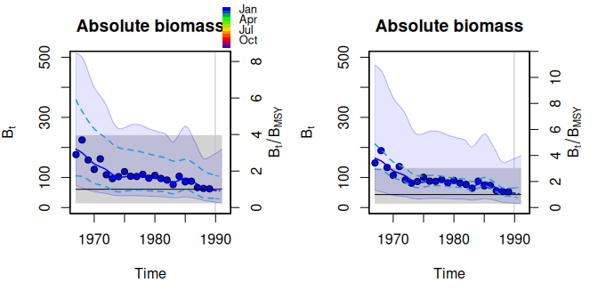

```r
inp <- pol$albacore
inp$priors$logB <- c(log(80), 0.1, 1, 1980)
par(mfrow=c(1, 2), mar=c(5, 4.1, 3, 4))
plotspict.biomass(fit.spict(pol$albacore), ylim=c(0, 500))
plotspict.biomass(fit.spict(inp), qlegend=FALSE, ylim=c(0, 500))
```

This imposes a Gaussian prior on `logB` with mean $\log(80)$, standard deviation 0.1 (very informative), the third entry in the vector indicates that the prior is used, the fourth entry indicates the year to which the prior should be applied, here 1980.

It is clear from the plots that the prior influences the results significantly. Furthermore, it is not only the biomass in the year 1980 that is affected, but the information propagates forward and backward because all estimates are correlated. In reality such an informative prior is rarely available, however it may be possible to derive information about the absolute biomass from acoustic survey and swept area estimates. It is, however, critical that the standard deviation used reflects the quality of the information.

### 2.9.4 Setting priors on the standard deviation of multiple indices

It is possible to set a prior for on some or all noise terms of multiple biomass indices

```r
set.seed(123)
inp <- list(timeC=pol$albacore$timeC, obsC=pol$albacore$obsC)
inp$timeI <- list(pol$albacore$timeI, pol$albacore$timeI[10:23]+0.25)
inp$obsI <- list()
inp$obsI[[1]] <- pol$albacore$obsI * exp(rnorm(23, sd=0.1)) # Index 1
inp$obsI[[2]] <- 10*pol$albacore$obsI[10:23] # Index 2
inp$priors$logsdi <- list(c(1, 1, 0),          # No prior for index 1
                          c(log(0.1), 0.2, 1)) # Set a prior on index 2
res <- fit.spict(inp)
sumspict.priors(res)

   Priors
        logn  ~  dnorm[log(2), 2^2]
    logalpha  ~  dnorm[log(1), 2^2]
     logbeta  ~  dnorm[log(1), 2^2]
     logsdi2  ~  dnorm[log(0.1), 0.2^2]
```

### 2.9.5 Fixing parameters using priors

Model parameters can be fixed using `phases` as described previously. This technique can, however, only be used to fix model parameters and therefore not derived quantities such as `logalpha`, `logr` (which is derived from `logK`, `logm` and `logn`). Fixing a parameter can be regarded as imposing an highly informative prior to the parameter

```r
inp <- pol$albacore
inp$priors$logn <- c(log(2), 1e-3)
inp$priors$logalpha <- c(log(1), 1e-3)
inp$priors$logbeta <- c(log(1), 1e-3)
fit.spict(inp)
   Convergence: 0  MSG: relative convergence (4)
   Objective function at optimum: -13.3777233
   Euler time step (years):  1/16 or 0.0625
   Nobs C: 23,  Nobs I1: 23

   Priors
        logn  ~  dnorm[log(2), 0.001^2] (fixed)
    logalpha  ~  dnorm[log(1), 0.001^2] (fixed)
     logbeta  ~  dnorm[log(1), 0.001^2] (fixed)

   Model parameter estimates w 95% CI
              estimate      cilow       ciupp    log.est
    alpha    1.0000039  0.9980459   1.0019658  0.0000039
    beta     0.9999976  0.9980396   1.0019595 -0.0000024
    r        0.5046213  0.1875616   1.3576486 -0.6839470
    rc       0.5046223  0.1875615   1.3576536 -0.6839451
    rold     0.5046232  0.1875608   1.3576639 -0.6839433
    m       22.0086912 17.0614724  28.3904271  3.0914374
    K      174.4568860 74.7565755 407.1241209  5.1616776
    q        0.3549422  0.1279007   0.9850140 -1.0358003
    n        1.9999964  1.9960803   2.0039201  0.6931454
    sdb      0.0966006  0.0704060   0.1325409 -2.3371705
    sdf      0.2102260  0.1562934   0.2827692 -1.5595724
    sdi      0.0966010  0.0704064   0.1325411 -2.3371666
    sdc      0.2102254  0.1562931   0.2827683 -1.5595748

   Deterministic reference points (Drp)
            estimate      cilow       ciupp   log.est
    Bmsyd 87.2283816 37.3782167 203.5621604  4.468530
    Fmsyd  0.2523111  0.0937808   0.6788268 -1.377092
    MSYd  22.0086912 17.0614724  28.3904271  3.091437
   Stochastic reference points (Srp)
            estimate      cilow       ciupp   log.est rel.diff.Drp
    Bmsys 86.1721662 37.1712853 199.7682395  4.456347 -0.012257036
    Fmsys  0.2500268  0.0921878   0.6781096 -1.386187 -0.009136328
    MSYs  21.5429417 16.5473975  28.0466059  3.070048 -0.021619589

   States w 95% CI (inp$msytype: s)
                     estimate      cilow      ciupp    log.est
    B_1989.94      54.8231771 17.4451846 172.287127  4.0041130
    F_1989.94       0.4313749  0.1433962   1.297694 -0.8407777
    B_1989.94/Bmsy  0.6362052  0.3800251   1.065080 -0.4522342
    F_1989.94/Fmsy  1.7253144  0.9443708   3.152056  0.5454093

   Predictions w 95% CI (inp$msytype: s)
                   prediction      cilow      ciupp    log.est
    B_1991.00      50.1747586 14.1661703 177.712561  3.9155121
    F_1991.00       0.4313751  0.1324968   1.404446 -0.8407772
    B_1991.00/Bmsy  0.5822618  0.2912706   1.163965 -0.5408351
    F_1991.00/Fmsy  1.7253153  0.8254232   3.606287  0.5454098
    Catch_1990.00  22.6023878 14.8442487  34.415210  3.1180556
    E(B_inf)       20.7048401         NA         NA  3.0303675
```

The summary indicates that the priors are so informative that the quantities are essentially fixed. It is also noted that the estimates of these quantities are very close to the mean of their respective priors.

### 2.9.6 Pitfalls when fixing parameters and specifying priors

Particular caution is required when fixing a parameter that is highly correlated with other parameters because this will to some extent restrict the estimates of the correlated parameters. This could also be a problem when specifying priors depending on the amount of a priori information available.

## 2.10 Robust estimation (reducing influence of extreme observations)

The presence of extreme observations may inflate estimates of observation noise and increase the general uncertainty of the fit. To reduce this effect it is possible to apply a robust estimation scheme, which is less sensitive to extreme observations. An example with an extreme observation in the catch series is

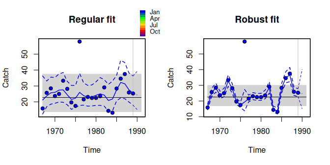

```r
inp <- pol$albacore
inp$obsC[10] <- 3*inp$obsC[10]
res1 <- fit.spict(inp)
inp$robflagc <- 1
res2 <- fit.spict(inp)
sumspict.parest(res2)
              estimate        cilow        ciupp    log.est
   alpha    8.01383381   1.14068241  56.30097518  2.0811693
   beta     0.13903418   0.02002496   0.96532028 -1.9730355
   r        0.25685421   0.10125244   0.65158021 -1.3592466
   rc       0.73334985   0.13979381   3.84710869 -0.3101324
   rold     0.85759775   0.00140627 522.99805458 -0.1536201
   m       22.57344303  16.94368708  30.07375715  3.1167741
   K      202.06196020 137.06165173 297.88810541  5.3085744
   q        0.34766878   0.18846325   0.64136419 -1.0565050
   n        0.70049571   0.06409210   7.65608029 -0.3559670
   sdb      0.01371149   0.00196492   0.09568068 -4.2895209
   sdf      0.37086361   0.26568724   0.51767565 -0.9919209
   sdi      0.10988163   0.08106946   0.14893367 -2.2083516
   sdc      0.05156272   0.00843522   0.31519203 -2.9649564
   pp       0.95304961   0.72887564   0.99351802  3.0105755
   robfac  20.83563433   2.67338471 236.12369114  2.9874800
par(mfrow=c(1, 2))
plotspict.catch(res1, main='Regular fit')
plotspict.catch(res2, qlegend=FALSE, main='Robust fit')
```

It is evident from the plot that the presence of the extreme catch observation generally inflates the uncertainty of the estimated catches, while the robust fit is less sensitive. Robust estimation can be applied to index and effort data using `robflagi` and `robflage` respectively.

Robust estimation is implemented using a mixture of light-tailed and a heavy-tailed Gaussian distribution as described in Pedersen and Berg (2017). This entails two additional parameters (`pp` and `robfac`) that require estimation. This may not always be possible given the increased model complexity. In such cases these parameters should be fixed by setting their phases to `-1`.

## 2.11 Forecasting and management scenarios

### 2.11.1 Forecasting

Producing short-term forecasts entails minimal additional computing time and is part of the model fitting of SPiCT. The default settings can be altered by specifying the start and end of the forecast interval with the argument `maninterval` (= ‘management interval’). For example, if a one year forecast of the catch during 2021 is of interest, then `maninterval` is set to represent the start and end of the forecast interval: `c(2021,2022)`. In addition to the forecast interval, a fishing scenario can be specified. This is done by specifying a factor (`ffac`) that is a fishing mortality multiplier at the start of the forecast period by. By default, the fishing mortality is unaltered and projected forward maintaining potential seasonal patterns. The time point of the forecasted biomass and fishing mortality can be controlled by setting `maneval` (= ‘management evaluation’). The code to obtain the forecasted annual catch in the interval starting 1990 under a management scenario where the fishing pressure is reduced by 25% starting in 1990, and the time point of forecasted biomass and fishing mortality in 1991 is:

```r
inp <- pol$albacore
inp$maninterval <- c(1990, 1991)
inp$maneval <- 1991
inp$ffac <- 0.75
rep <- fit.spict(inp)
```

To specifically show forecast results use

```r
sumspict.predictions(rep)
                  prediction      cilow      ciupp     log.est
   B_1991.00      59.6456284 32.5515447 109.291311  4.08842086
   F_1991.00       0.3348379  0.1179797   0.950302 -1.09410887
   B_1991.00/Bmsy  0.9820403  0.2791400   3.454908 -0.01812295
   F_1991.00/Fmsy  0.9006311  0.1792990   4.523932 -0.10465954
   Catch_1990.00  19.4447493 11.7527492  32.171049  2.96757707
   E(B_inf)       67.1854952         NA         NA  4.20745738
```

These predictions are also shown when using `summary(rep)` and as with any spict object the results can be plotted using `plot(rep)`. Here, however, we use a selection of 4 graphs to visualise the change in forecasted fishing mortality and associated change in forecasted catch more clearly:

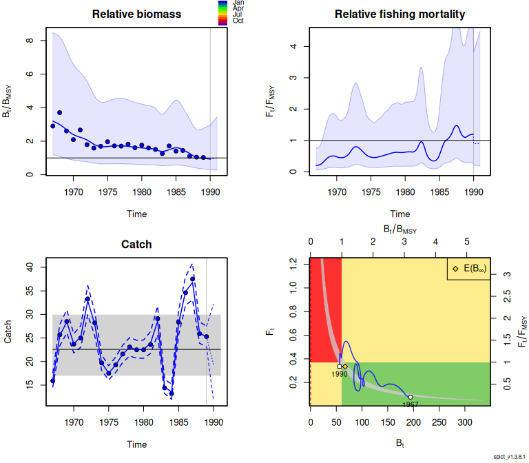

```r
plot2(rep)
```

The dotted lines in the graph represent the predicted quantities for the forecast interval. Note the clear drop and subsequent constant fishing mortality representing the 25% reduction in fishing pressure as set with `ffac`. The decrease in fishing pressure results in constant (slightly increasing) biomass as opposed to the expected decrease if fishing effort had remained constant. The larger confidence intervals indicate the larger uncertainty associated with model predictions without data. Setting `ffac` (or `fcon` for changing the fishing mortality by an absolute value instead of a factor) in the input list affects any SPiCT fit with this input list. This can be reversed back to the default (continuing the F process) by setting `inp$ffac <- NULL`. In the following section, we introduce a range of different functions which make the exploration of different F factors and other management strategies more straight-forward and do not affect the fitted SPiCT object or its input list.